# Gross, J. J., Uusberg, H., & Uusberg, A. (2019).

Mental illness and well-being: An affect regulation perspective. World Psychiatry, 18(2), 130–139. https://doi.org/10.1002/wps.20618

Last update at: 2023-07-11

Back to index

# Abstract / Key Points

Basically a shorter version of Gross 2015

Definition of mental health (WHO):

“mental health is a state of well-being in which the individual realizes his or her own abilities, can cope with the normal stresses of life, can work productively and fruitfully, and is able to make a contribution to his or her community”

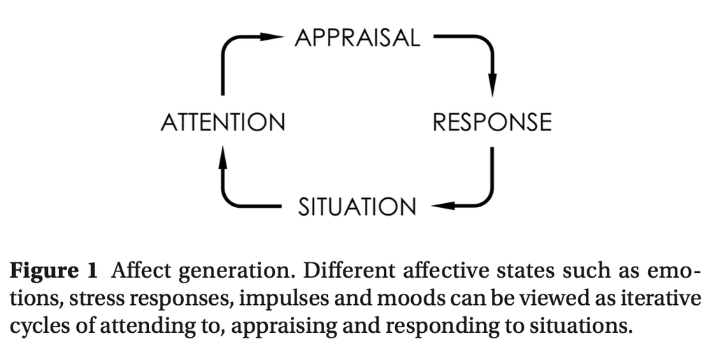

All affective states share a common dimension: valuation (i.e., good-for-me vs. bad-for-me). The function of affective states is to shape behavior in accordance with the relationship between situation and motivational concerns.

affective states, including the following (in hierarchical order [continuum] based on how many affect generation stages are generally part of the conscious experience of the given affective state, p.131)

- emotions: all four stages are generally part of the experience
- stress: appraisal + response; experiences revolve around broader circumstances (e.g., new job, divorce) that span several specific situations
- impulses: response and situation
- mood: diffuse feelings and action tendencies; tends to relate to situations that have been selectively perceived and appraised largely outside of awareness

the model also suggests that unhealthy affect can be traced back to maladaptive unfolding of one or more of the four affect genera- tion stages.

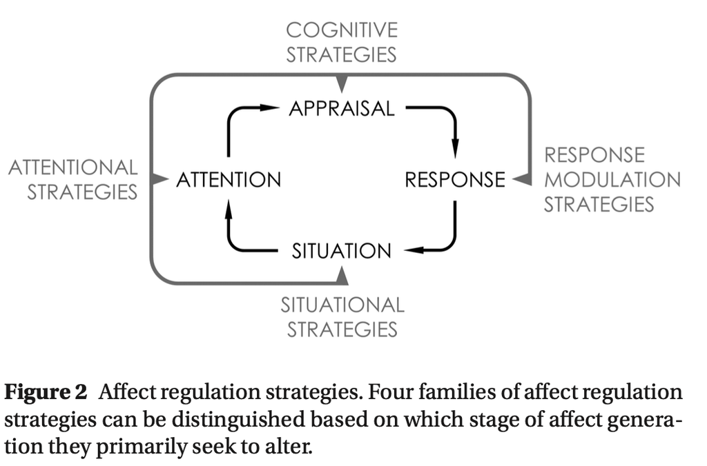

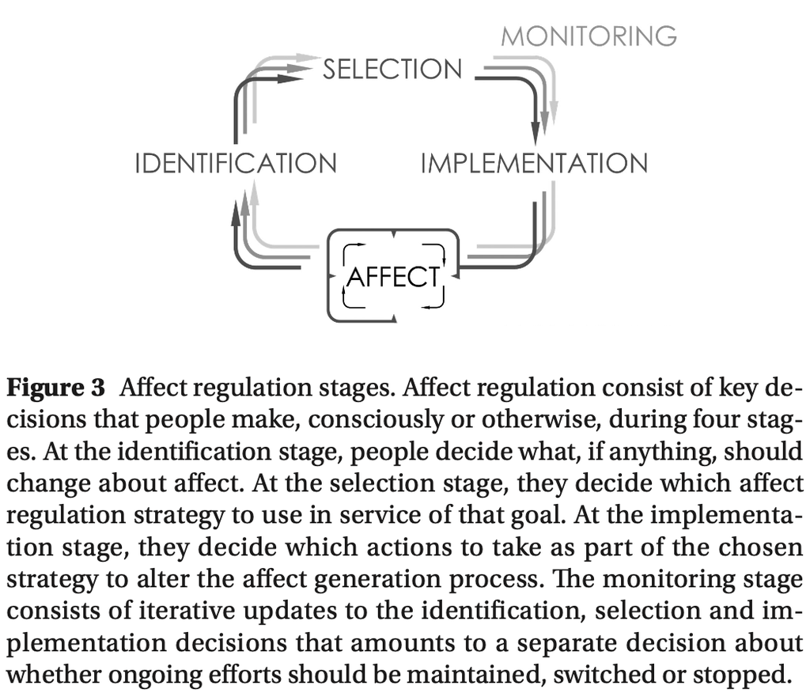

Back to index